# New universal matK primers for DNA barcoding angiosperms - YU - 2011 - Journal of Systematics and Evolution - Wiley Online Library

[Journal of Systematics and Evolution](https://onlinelibrary.wiley.com/journal/17596831)

[Volume 49, Issue 3](https://onlinelibrary.wiley.com/toc/17596831/2011/49/3) p. 176-181

[figure not shown]

Research Article

Free Access

# New universal *matK* primers for DNA barcoding angiosperms

[Jing YU](https://onlinelibrary.wiley.com/authored-by/ContribAuthorRaw/YU/Jing),

[Jian-Hua XUE](https://onlinelibrary.wiley.com/authored-by/ContribAuthorRaw/XUE/Jian%E2%80%90Hua),

[Shi-Liang ZHOU](https://onlinelibrary.wiley.com/authored-by/ContribAuthorRaw/ZHOU/Shi%E2%80%90Liang),

First published: 21 March 2011

https://doi.org/10.1111/j.1759-6831.2011.00134.x

Citations: 102

## Abstract

**Abstract** The chloroplast maturase K gene (*matK*) is one of the most variable coding genes of angiosperms and has been suggested to be a “barcode” for land plants. However, *matK* exhibits low amplification and sequencing rates due to low universality of currently available primers and mononucleotide repeats. To resolve these technical problems, we evaluated the entire *matK* region to find a region of 600–800 bp that is highly variable, represents the best of all *matK* regions with priming sites conservative enough to design universal primers, and avoids the mononucleotide repeats. After careful evaluation, a region in the middle was chosen and a pair of primers named *matK*472F and *matK*1248R was designed to amplify and sequence the *matK* fragment of approximately 776 bp. This region encompasses the most variable sites, represents the entire *matK* region best, and also exhibits high amplification rates and quality of sequences. The universality of this primer pair was tested using 58 species from 47 families of angiosperm plants. The primers showed a strong amplification (93.1%) and sequencing (92.6%) successes in the species tested. We propose that the new primers will solve, in part, the problems encountered when using *matK* and promote the adoption of *matK* as a DNA barcode for angiosperms.

DNA barcoding, a concept that has recently become popular, is characterized by using one or a few DNA fragments to identify different species (Kress et al., 2005). The mitochondrial cytochrome *c* oxidase subunit 1 (*CO1*) gene was selected to be a DNA barcode for animal species (Hebert et al., 2003). However, consensus is still to be reached regarding gene fragments for a plant DNA barcode, although the Consortium for the Barcode of Life (CBOL) Plant Working Group (2009) has suggested *matK + rbcL*. The difficulty in selecting specific genes to be a plant barcode is due to the imperfection of any gene from either the chloroplast, mitochondrial, or nuclear genomes. The plant mitochondrial genes evolve slowly and, therefore, are ineffective for distinguishing between different plant species. Plant nuclear genes often occur in multiple copies and are highly variable, making the design of universal primers difficult. The search for a plant DNA barcode has focused on genes of the chloroplast genome and several candidates, such as *acc*D, *atpF–atpH*, *matK, nhdJ*, *psbK–psbI*, *rbcL*, *rpoB*, *rpo*C1, and *trnH–psbA* have been proposed (Chase et al., 2005; Kress et al., 2005; Newmaster et al., 2006; Yoo et al., 2006). Unfortunately, very few of these loci are variable enough to identify or distinguish between plant species when used alone, leading to the use of several combinations of loci, such as *rpoC1*+*rpoB*+*matK*, *rpoC1*+*matK + trnH–psbA*, *rbcL*+*trnH–psbA*, *matK*+*atpF-H*+*psbK-I*, and *matK + atpF-H + trnH–psbA* (Yoo et al., 2006; Chase et al., 2007; Kress & Erickson, 2007; CBOL Plant Working Group, 2009).

Among the candidate barcode genes, *matK* is one of the most promising candidates for a plant barcode. The *matK* gene is approximately 1570 bp in length and codes for a maturase protein. The coding region of *matK* is generally located within an intron of the chloroplast *trnK* gene, except in some ferns, in which it encodes tRNA<sup>Lys</sup>(UUU) (Neuhaus & Link, 1987). Being a coding region, the very high evolutionary rate of *matK* has made it usable in phylogenetic reconstructions at high taxonomic levels, such as Order or Family, and sometimes also at low taxonomic levels, such as Genus or Species (Wolfe, 1991; Hilu et al., 2003; Müller et al., 2006; Chase et al., 2007; Lahaye et al., 2008). Although extensive divergence in the *matK* sequence for higher taxonomic categories results in questionable positions and relationships of some phylogenetic clades, *matK* is very useful in DNA barcoding for the identification of plant families (Qiu et al., 1999; Li & Zhou, 2007; Gao et al., 2008).

Despite these issues, *matK* remains one of the best choices for plant DNA barcoding. Determination of the individual region of *matK* that best represents the entire gene and design of additional universal primers is an important next step. In the present study, we first determined the individual region of *matK* that best represents the entire gene and then designed primers in adjacent and more conserved regions of the area. The universality of the new primers is tested by amplifying and sequencing some samples selected randomly from 33 orders. The ultimate goal of the present study was to provide new alternative primers for *matK* for use in plant DNA barcoding.

## 1 Material and methods

### 1.1 *matK* sequence analysis and primer design

The *matK* gene sequences were obtained from 106 chloroplast genomes available from GenBank, aligned using Clustal X 2.0 (Larkin et al., 2007), and adjusted manually with Se-Al Version 2.0 a11 (Rambaut, 1996; Larkin et al., 2007). Ten 600-bp data subsets were generated by sampling the data set of the entire length and analyzed with PAUP 4.0b10 (Swofford, 2000) to reconstruct the phylogeny. COMPONENT Version 2.00a software (Page, 1993) was used to calculate the distances between the phylogenetic trees based on the entire gene length and the subsets with the smallest distance considered to be the best representative of the entire length. Variability of *matK* was estimated by DNAsp Version 5.0 (Librado & Rozas, 2009) using the sliding window method. Conserved regions were identified and primers were designed with the help of Primer Premier 5.0 (Premier Biosoft International, Palo Alto, CA, USA).

### 1.2 Amplification and sequencing with new primers

Gradient PCR was performed using five samples representing basal angiosperms, monocots, basal eudicots, rosids, and asterids in order to determine the optimum annealing temperatures of the newly designed primers *matK*472F (5′-CCC RTY CAT CTG GAA ATC TTG GTT C-3′) and *matK*1248R (5′-GCT RTR ATA ATG AGA AAG ATT TCT GC-3′). The universality of the primers was tested using 58 samples from 47 families (7 species from 6 families of basal angiosperms, 12 species from 10 families of monocots and 39 species from 31 families of dicots, Table S1), with 390F/1326R as a control. Total DNA was extracted using the cetyltrimethyl ammonium bromide (CTAB) method (Doyle & Doyle, 1987). The PCR reaction mixture consisted of 1× PCR buffer, 0.5 mmol/L dNTPs, 0.25 μmol/L each primer, 1 U Taq polymerase, and 5–50 ng template DNA. Thermal cycling conditions were as follows: 94 °C for 3 min, followed by 40 cycles of 94 °C for 30 s, 48 °C for 40 s, 72 °C for 1 min, and a final extension at 72 °C for 10 min. The PCR products were verified by electrophoresis in 1% agarose gels stained with ethidium bromide. Repetitions of PCR were performed again under the same conditions for those samples of no band or weak bands. The PCR products were sent to the Beijing Genomic Institute (BGI; Shenzhen, China) for sequencing after simple purification. Sequences were analyzed by Sequencher 4.7 (Gene Codes, Ann Arbor, MI, USA).

## 2 Results

### 2.1 Variability of the *matK* region and priming sites

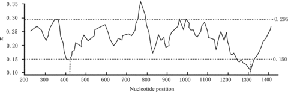

**Figure 1**

Variability of *matK* sequences of seed plants parameterized by nucleotide diversity (π). Four peaks (above the upper horizontal dotted line) indicate the most variable regions and two valleys (indicated by vertical dotted lines) mark the most conservative regions.

### 2.2 Most representative segments of the entire length of *matK*

Using the length of the *CO1* gene as a reference, the total length of *matK* was sequentially grouped into 10 data subsets of 600 bp, with 100-bp intervals. Results from the neighbor joining (NJ) method showed that data subset 8 best represented the entire length, followed by data subsets 9 and 7. However, the maximum parsimony (MP) method suggested data subset 7 and the maximum likelihood (ML) method suggested data subset 9 (Table 1). Taken together, the sequences from 600 to 1400 bp are more representative of the entire length than the other regions, according to the relatively smaller distances.

Table 1. Distances between the phylogenetic tree based on the entire length of *matK* sequences and the trees based on the length of 600 bp

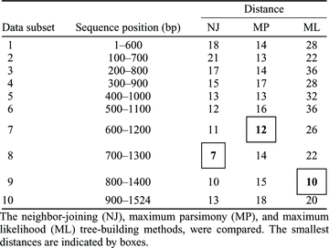

### 2.3 Priming sites, primer universality, PCR amplification, and sequencing successes

The exact sites of the primers were adjusted within the two most conserved regions for better priming and excluding a poly-A region. The priming site of *matK*472F is roughly at the same area as 2.1F/2.1aF and AST_F/*matK*_KewR/1R_KIM, and the *matK*1248R overlaps partly with MALV_R1 (Fig. 2). Gradient PCR revealed an optimum temperature below 52 °C for *matK*472F and *matK*1248R, with the strongest bands at 48 °C. However, some samples amplified well at 60 °C. Therefore, an annealing temperature range of 48–52 °C can be considered feasible. In total, 58 samples (Table S1) were amplified and sequenced using the primer pair *matK*472F/*matK*1248R, with 390F/1326R as a control in amplification under the same conditions. The primers worked well for angiosperms, with an average amplification success of 93.1% compared with 25.9% in the control (Table 2). Most amplicons were strong enough for isolation of bands or direct sequencing. Although weak bands were observed, no apparently adverse effects were detected. After trimming off the two ends of low quality, the average sequence length of reads was 684 bp, with a mean quality value 97.8%, using *matK*472F and 655 bp, with a mean quality value 94.7%, using *matK*1248R.

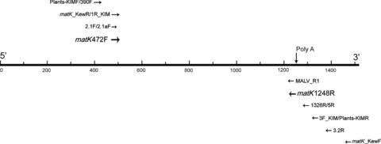

**Figure 2**

The position and orientation of the new *matK* primer pair *matK*472F +*matK*1248R and some other primers on the entire length of the *matK* gene of *Arabidopsis thaliana* (1515 bp). The primer sequences are given in Table S2.

Table 2. Universality test for the newly designed primer pair *matK*472F and *matK*1248R with 390F + 1326R as a control

| Order | *n* | *matK*472F +*matK*1248R *n1* | *matK*472F +*matK*1248R *n1*/*n* (%) | *matK*472F +*matK*1248R *n2* | *matK*472F +*matK*1248R *n2*/*n1* (%) | Control *n3* | Control *n3*/*n* (%) |
| --- | --- | --- | --- | --- | --- | --- | --- |
| Angisperms | 58 | 54 | 93.1 | 50 | 92.6 | 15 | 25.9 |
| Basal angiosperms | 7 | 7 | 100 | 6 | 85.7 | 3 | 42.9 |
| Monocots | 12 | 11 | 91.7 | 11 | 100 | 5 | 41.7 |
| Eudicots | 39 | 36 | 92.3 | 33 | 91.7 | 7 | 17.9 |
| Basal eudicots | 6 | 5 | 83.3 | 5 | 100 | 0 | 0 |
| Asterids | 12 | 11 | 91.7 | 10 | 90.9 | 3 | 25 |
| Rosids | 21 | 20 | 95.2 | 18 | 90.0 | 4 | 19.0 |
| Total | 58 | 54 | 93.1 | 50 | 92.6 | 15 | 25.9 |

- *n*, number of samples (species) used; *n1*, number of samples amplified successfully; *n2*, number of samples sequenced successfully; *n3*, number of samples amplified successfully using 390F and 1326R.

## 3 Discussion

The major problem of using *matK* as a barcode is the difficulty in amplifying and sequencing the gene fragments. Early studies adopted a strategy of using the more highly conserved *trnK* regions as priming positions for fragment amplification and several internal primers for sequencing. The internal primers were typically designed for specific taxa and the universality was limited (Fazekas et al., 2008). Of the primers designed, primer pair 390F/1326R is one pair of the best, as exemplified by Lahaye et al. (2008), although in the present study the amplification success was only 25.9%. Within the *matK* region there are a few hot spots for designing primers (Fig. 2). There are two major hot spots for forward primers: one is represented by 390F and the other by 1R_KIM. The *matK*472F falls in the second hot spot. The reverse primers were tiered mainly at three positions represented by 3F_KIM, 1326R, and *matK*_KewR. The *matK*1248R happens to overlap partially with MALV_R1. The new primers produce significantly improved amplification success for angiosperms. Many primers designed within the *matK* gene amplify fragments that may include a long mononucleotide repeat, which may cause problems in sequencing. The new primer pair excludes that region and thereby may increase sequencing success and quality.

There are many possible regions of the entire *matK* gene that may be used as a plant barcode. We determined the region from 600 to 1400 bp to be the best representative of the whole-gene sequence based on the smallest distances (Table 1). Considering the conservative regions for primer design and the mononucleotide repeats that cause sequencing problems, the final region of *matK* was adjusted to contain the sequence from 472 to 1248 bp. The new primers were named according to the starting and ending sites of the whole *matK* gene sequence of *Arabidopsis thaliana*.

Although *matK*472F +*matK*1248R worked reasonably well for the samples tested, its usefulness for all angiosperms needs to be evaluated. To avoid using too many degenerate bases, we have to ignore rare base substitutions. More specific primers can be designed by modifying *matK*472F and *matK*1248R according to the desired sequence. Failure of amplification can also be attributed to a low quality of template DNA. Amplification of the same samples was significantly enhanced after purifying the DNA. The new primer pair identified in the present study is able to function over a broad range of annealing temperatures (from 38 to 52 °C, or even to 60 °C). We suggest using an annealing temperature of 48–52 °C for this pair of primers. However, performing an initial gradient PCR will identify the best annealing temperature before performing many amplifications. Additional optimization methods for PCR can be found in standard DNA barcoding protocols (Chase et al., 2007).

The sequences obtained using the primers given are the best representatives of the whole *matK* region and are thus of phylogenetic value. Taking the representative together with the variability of barcoding regions into consideration will potentiate species identification using phylogenetic methods when species delimitations are problematic.

## Acknowledgments

**Acknowledgements** This study was supported by the Research Fund for the Large-scale Scientific Facilities of the Chinese Academy of Sciences (grant no. 2009-LSF-GBOWS-01 and KSCX2-YW-N-0807).

May 2011

Pages 176-181